# `Bank Churn Prediction`

## `Domain:`

Banking

## `Description:`

Businesses like banks that provide service have to worry about the problem of 'Churn' i.e. customers leaving and joining another service provider. It is important to understand which aspects of the service influence a customer's decision in this regard. Management can concentrate efforts on the improvement of service, keeping in mind these priorities.

## `Attributes Information:`

The case study is from an open-source dataset from Kaggle. The dataset contains 10,000 sample points with 14 distinct features such as CustomerId, CreditScore, Geography, Gender, Age, Tenure, Balance, etc.

Link to the Kaggle project site:https://www.kaggle.com/barelydedicated/bank-customer-churn-modeling

[output not shown]

## `Objective:`

Given the bank's customers data, build a neural network-based classifier that can determine whether they will leave or not in the next 6 months.

## `Steps and tasks`

1. Libraries & Dataset Import
2. EDA
1. Univariate Analysis
2. Bivariate Analysis
3. Getting data ready
3. Building ANN model
1. Model review
2. Predicting the results using 0.5 as a threshold
3. Scores and Confusion matrix
4. Conclusions

## 1. Libraries & Dataset Import

```python
# Basic imports
import pandas as pd
import numpy as np

# Plots
import matplotlib.pyplot as plt
%matplotlib inline
import seaborn as sns

import warnings
warnings.filterwarnings('ignore')

from IPython.core.display import display
```

```python
df = pd.read_csv('bank.csv')
df.head()
```

|  | RowNumber | CustomerId | Surname | CreditScore | Geography | Gender | Age | Tenure | Balance | NumOfProducts | HasCrCard | IsActiveMember | EstimatedSalary | Exited |
| --- | --- | --- | --- | --- | --- | --- | --- | --- | --- | --- | --- | --- | --- | --- |
| 0 | 1 | 15634602 | Hargrave | 619 | France | Female | 42 | 2 | 0.00 | 1 | 1 | 1 | 101348.88 | 1 |
| 1 | 2 | 15647311 | Hill | 608 | Spain | Female | 41 | 1 | 83807.86 | 1 | 0 | 1 | 112542.58 | 0 |
| 2 | 3 | 15619304 | Onio | 502 | France | Female | 42 | 8 | 159660.80 | 3 | 1 | 0 | 113931.57 | 1 |
| 3 | 4 | 15701354 | Boni | 699 | France | Female | 39 | 1 | 0.00 | 2 | 0 | 0 | 93826.63 | 0 |
| 4 | 5 | 15737888 | Mitchell | 850 | Spain | Female | 43 | 2 | 125510.82 | 1 | 1 | 1 | 79084.10 | 0 |

```python
df.shape
```

```
(10000, 14)
```

## 2. EDA

### Univariate Analysis

First of all let us drop the features that are not helpful for our objective. We will drop **RowNumber**, **CustomerId** and **Surname**. **RowNumber** and **CustomerId** are identifiers brining no additional information other than idea of an id. **Surname** we also can consider as a sort of identifier, and knowing that some customers have the same surname gives us no useful information either.

```python
cdf = df.copy()
cdf.drop(['RowNumber', 'CustomerId', 'Surname'], axis=1, inplace=True)
cdf.head()
```

|  | CreditScore | Geography | Gender | Age | Tenure | Balance | NumOfProducts | HasCrCard | IsActiveMember | EstimatedSalary | Exited |
| --- | --- | --- | --- | --- | --- | --- | --- | --- | --- | --- | --- |
| 0 | 619 | France | Female | 42 | 2 | 0.00 | 1 | 1 | 1 | 101348.88 | 1 |
| 1 | 608 | Spain | Female | 41 | 1 | 83807.86 | 1 | 0 | 1 | 112542.58 | 0 |
| 2 | 502 | France | Female | 42 | 8 | 159660.80 | 3 | 1 | 0 | 113931.57 | 1 |
| 3 | 699 | France | Female | 39 | 1 | 0.00 | 2 | 0 | 0 | 93826.63 | 0 |
| 4 | 850 | Spain | Female | 43 | 2 | 125510.82 | 1 | 1 | 1 | 79084.10 | 0 |

```python
cdf.info()
```

```
<class 'pandas.core.frame.DataFrame'>
RangeIndex: 10000 entries, 0 to 9999
Data columns (total 11 columns):
 #   Column           Non-Null Count  Dtype
---  ------           --------------  -----
 0   CreditScore      10000 non-null  int64
 1   Geography        10000 non-null  object
 2   Gender           10000 non-null  object
 3   Age              10000 non-null  int64
 4   Tenure           10000 non-null  int64
 5   Balance          10000 non-null  float64
 6   NumOfProducts    10000 non-null  int64
 7   HasCrCard        10000 non-null  int64
 8   IsActiveMember   10000 non-null  int64
 9   EstimatedSalary  10000 non-null  float64
 10  Exited           10000 non-null  int64
dtypes: float64(2), int64(7), object(2)
memory usage: 859.5+ KB
```

```python
cdf.isnull().sum()
```

```
CreditScore        0
Geography          0
Gender             0
Age                0
Tenure             0
Balance            0
NumOfProducts      0
HasCrCard          0
IsActiveMember     0
EstimatedSalary    0
Exited             0
dtype: int64
```

**Insights:**

- There are 10000 customers in the dataset.
- There are no NULL values.

```python
cdf.nunique()
```

```
CreditScore         460
Geography             3
Gender                2
Age                  70
Tenure               11
Balance            6382
NumOfProducts         4
HasCrCard             2
IsActiveMember        2
EstimatedSalary    9999
Exited                2
dtype: int64
```

**Insights:**

- **Geography** has **3** locations.
- **Gender** has **2** unique values which is expexted.
- We have several **Yes/No** variables. Two input - **HasCrCard** and **IsActiveMember**, one traget variable **Exited**.

Let's have a look at numerical variables.

```python
cdf[['CreditScore', 'Age', 'Tenure', 'Balance', 'NumOfProducts', 'EstimatedSalary']].describe().T
```

|  | count | mean | std | min | 25% | 50% | 75% | max |
| --- | --- | --- | --- | --- | --- | --- | --- | --- |
| CreditScore | 10000.0 | 650.528800 | 96.653299 | 350.00 | 584.00 | 652.000 | 718.0000 | 850.00 |
| Age | 10000.0 | 38.921800 | 10.487806 | 18.00 | 32.00 | 37.000 | 44.0000 | 92.00 |
| Tenure | 10000.0 | 5.012800 | 2.892174 | 0.00 | 3.00 | 5.000 | 7.0000 | 10.00 |
| Balance | 10000.0 | 76485.889288 | 62397.405202 | 0.00 | 0.00 | 97198.540 | 127644.2400 | 250898.09 |
| NumOfProducts | 10000.0 | 1.530200 | 0.581654 | 1.00 | 1.00 | 1.000 | 2.0000 | 4.00 |
| EstimatedSalary | 10000.0 | 100090.239881 | 57510.492818 | 11.58 | 51002.11 | 100193.915 | 149388.2475 | 199992.48 |

**Insights:**

- **CreditScore** has close mean & median. Also all the values are in the expected range of **300-900**.
- **Age** also has close mean and median. We see that acual age range for the customers is **18-92** years.
- Similar picture for **Tenure**, close mean & median, range is **0-10**.
- For **Balance** on the other hand we see considerable skew. We don't see any negative balances, however **25%** of customers have **0** balance.
- **EstimatedSalary** again has close mean and median. Some estimated salaries look strange, for instance the minimum of **11.58**.
- **NumOfProducts** variable indicates that **50%** of customers have just **1** card/product. The range is **1-4**.

```python
duplicate_count = cdf.duplicated(keep='first').sum()
print('Total duplicates: ', duplicate_count)
```

```
Total duplicates:  0
```

**Insights:**

- No **duplicates** in this dataset.

#### Define Utility Functions

```python
def plot_counts_percentages(data, col, vr=0):
    total_clients = data.shape[0]
    chart = sns.countplot(data[col], order = data[col].value_counts().index, palette='muted');
    chart.set(title=col.title(), xlabel='', ylabel='Count')
    chart.set_xticklabels(chart.get_xticklabels(),  rotation=vr)
    for p in chart.patches:
        height = p.get_height()
        chart.text(p.get_x() + p.get_width()/2., height + 3, '{:1.2f}'.format((height/total_clients)*100), ha='center')

def display_num_stat_graph(data, col, hist_color='seagreen', hist_mean='tomato', hist_median='steelblue', box_color='steelblue'):
    f = plt.figure(figsize=(15,5))
    gs = f.add_gridspec(1, 2)

    with sns.axes_style("whitegrid"):
        ax = f.add_subplot(gs[0, 0])
        sns.distplot(data[col], color=hist_color, kde=True, rug=True)
        ax.axvline(data[col].mean(), color = hist_mean, label='Mean')
        ax.axvline(data[col].median(), color = hist_median, label='Median')
        ax.legend()

    with sns.axes_style("darkgrid"):
        ax = f.add_subplot(gs[0, 1])
        sns.boxplot(x=data[col], notch = True, whis = 1.5, color=box_color)

    f.tight_layout()
    plt.show()

def printc(text, color):
    colors = {
        'black':'\033[30m',
        'red':'\033[31m',
        'green':'\033[32m',
        'orange':'\033[33m',
        'blue':'\033[34m',
        'purple':'\033[35m',
        'cyan':'\033[36m',
        'lightgrey':'\033[37m',
        'darkgrey':'\033[90m',
        'lightred':'\033[91m',
        'lightgreen':'\033[92m',
        'yellow':'\033[93m',
        'lightblue':'\033[94m',
        'pink':'\033[95m',
        'lightcyan':'\033[96m'
    }
    style = {
        'reset':'\033[0m',
        'bold':'\033[01m'
    }

    print(colors[color], text, style['reset'])


def display_num_skew_outliers(data, col):
    # Computing IQR
    Q1 = data[col].quantile(0.25)
    Q3 = data[col].quantile(0.75)
    IQR = Q3 - Q1
    LowerWhisker = Q1 - 1.5 * IQR
    MinValue = data[col].min()
    UpperWhisker = Q3 + 1.5 * IQR
    MaxValue = data[col].max()

    # Update whiskers
    LowerWhisker = max(MinValue, LowerWhisker)
    UpperWhisker = min(MaxValue, UpperWhisker)

    # Outliers
    LowerOutliers = data[data[col] < LowerWhisker][col]
    LowerOutliersCount = LowerOutliers.count()
    UpperOutliers = data[data[col] > UpperWhisker][col]
    UpperOutliersCount = UpperOutliers.count()

    print('>', col.title())
    printc('Mean         : {}'.format(data[col].mean()), 'red')
    printc('Median       : {}'.format(data[col].median()), 'blue')
    print('Skew          :', data[col].skew())
    print('Lower whisker :', LowerWhisker)
    print('Upper whisker :', UpperWhisker)

    print('Outliers above upper whisker: ', UpperOutliersCount, '({:.1f}%)'.format( (UpperOutliersCount/data.shape[0])*100) )
    if(UpperOutliersCount > 0):
        print('  > (closest 15):', ', '.join(map(str, UpperOutliers.head(15))))

    print('Outliers under lower whisker: ', LowerOutliersCount, '({:.1f}%)'.format( (LowerOutliersCount/data.shape[0])*100) )
    if(LowerOutliersCount > 0):
        print('  > (closest 15):', ', '.join(map(str, LowerOutliers.head(15))))
```

Let's see the distribution for the variables with low number of unique values, namely **Geography**, **Gender**, **NumOfProducts**, **HasCrCard**, **IsActiveMember** and target **Exited**.

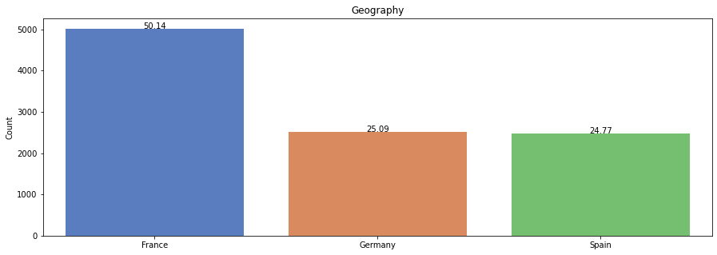

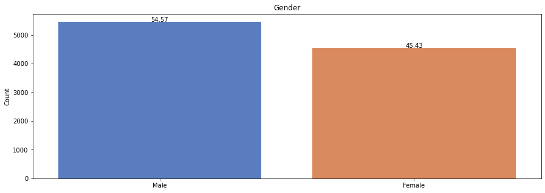

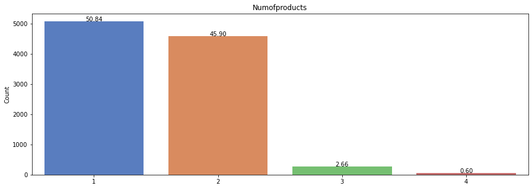

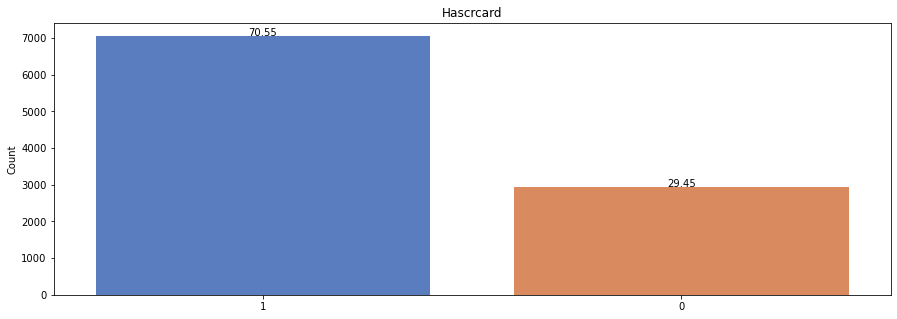

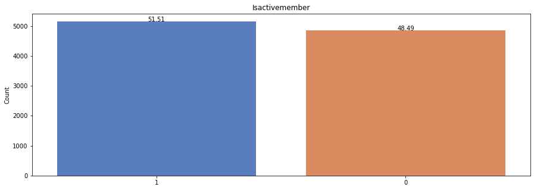

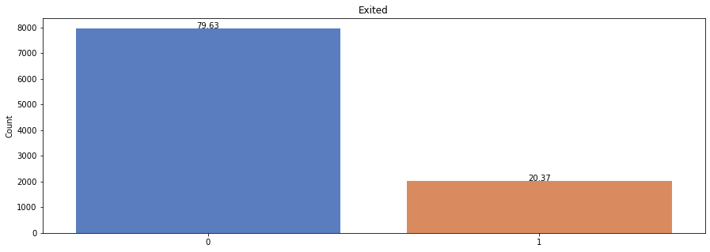

```python
for col in ['Geography', 'Gender', 'NumOfProducts', 'HasCrCard', 'IsActiveMember', 'Exited']:
    plt.figure(figsize=(15,5))
    plot_counts_percentages(cdf, col)
    plt.show()
```

**Insights:**

- **Geography** shows that **50%** of all customers are from France. Germany and Spain equally split the rest **50%**.
- We see a good **Gender** distribution, almost **50/50**.
- **96%** of the customers have **1-2** of the bank's products.
- **70%** have credit cards.
- Also good split for **active member** variable, almost **50/50**.
- However for out **target** variable **Exited** we don't have a good distribution and the data is definetely **biased** towards the customers who did not quit, roughly **80/20**, this is **imbalanced set**.

Let's check for outliers/skewness

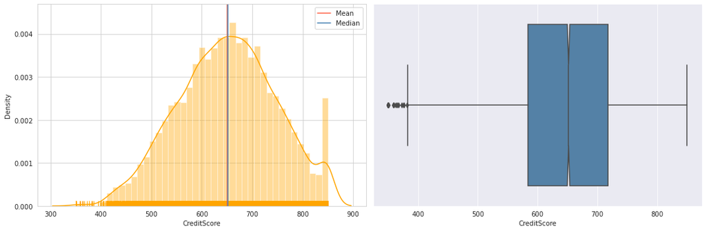

```
> Creditscore
 Mean         : 650.5288
 Median       : 652.0
Skew          : -0.07160660820092675
Lower whisker : 383.0
Upper whisker : 850
Outliers above upper whisker:  0 (0.0%)
Outliers under lower whisker:  15 (0.1%)
  > (closest 15): 376, 376, 363, 359, 350, 350, 358, 351, 365, 367, 350, 350, 382, 373, 350
```

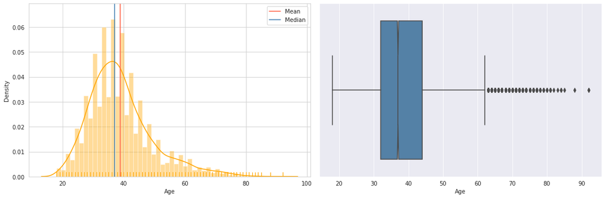

```
> Age
 Mean         : 38.9218
 Median       : 37.0
Skew          : 1.0113202630234552
Lower whisker : 18
Upper whisker : 62.0
Outliers above upper whisker:  359 (3.6%)
  > (closest 15): 66, 75, 65, 73, 65, 72, 67, 67, 79, 80, 68, 75, 66, 66, 70
Outliers under lower whisker:  0 (0.0%)
```

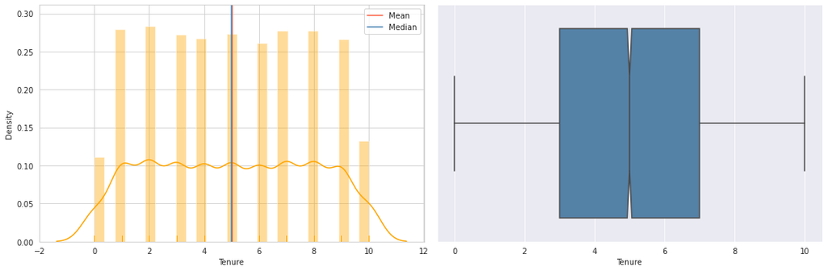

```
> Tenure
 Mean         : 5.0128
 Median       : 5.0
Skew          : 0.01099145797717904
Lower whisker : 0
Upper whisker : 10
Outliers above upper whisker:  0 (0.0%)
Outliers under lower whisker:  0 (0.0%)
```

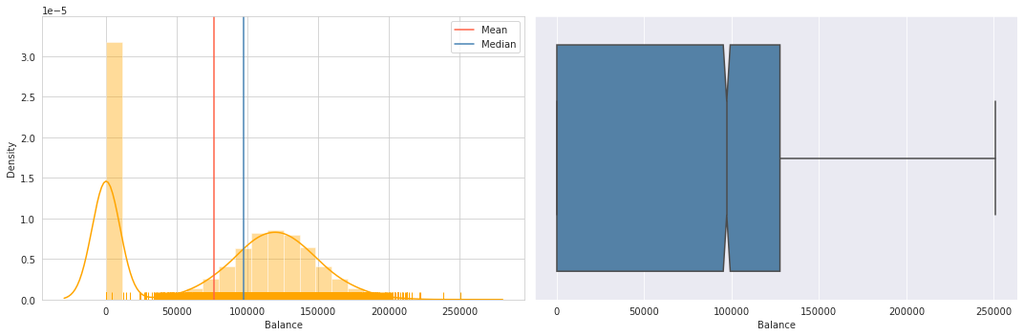

```
> Balance
 Mean         : 76485.88928799961
 Median       : 97198.54000000001
Skew          : -0.14110871094154384
Lower whisker : 0.0
Upper whisker : 250898.09
Outliers above upper whisker:  0 (0.0%)
Outliers under lower whisker:  0 (0.0%)
```

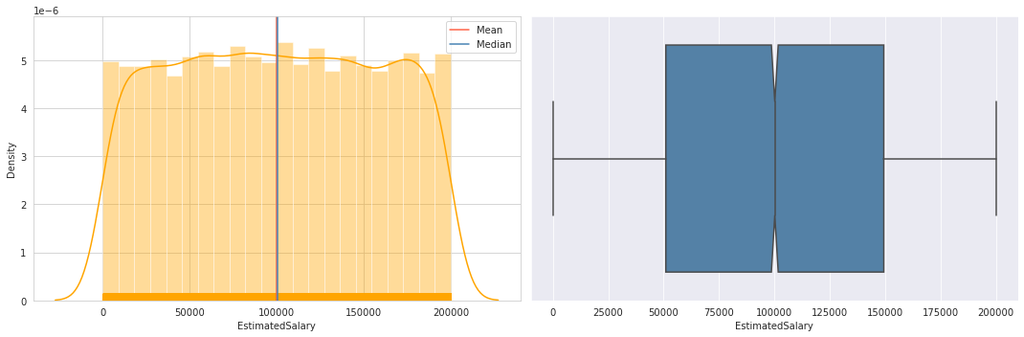

```
> Estimatedsalary
 Mean         : 100090.2398809998
 Median       : 100193.915
Skew          : 0.0020853576615585162
Lower whisker : 11.58
Upper whisker : 199992.48
Outliers above upper whisker:  0 (0.0%)
Outliers under lower whisker:  0 (0.0%)
```

```python
for col in ['CreditScore', 'Age', 'Tenure', 'Balance', 'EstimatedSalary']:
    display_num_stat_graph(cdf, col, hist_color='orange')
    display_num_skew_outliers(cdf, col)
```

**Insights:**

### Bivariate Analysis

- **Gender**

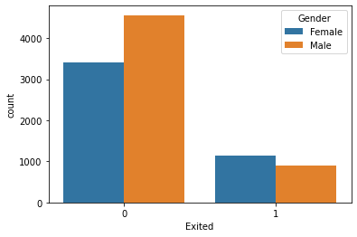

| Exited Gender | 0 | 1 |
| --- | --- | --- |
| Female | 0.749285 | 0.250715 |
| Male | 0.835441 | 0.164559 |

```python
sns.countplot(df['Exited'], hue=df['Gender'])
plt.show()
pd.crosstab(df['Gender'], df['Exited'], normalize='index')
```

**Insights:**

- Looking at **Gender** split, although a small difference, it seems that women tend to leave more often than men.
- **Geography**

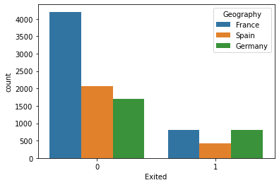

| Exited Geography | 0 | 1 |
| --- | --- | --- |
| France | 0.838452 | 0.161548 |
| Germany | 0.675568 | 0.324432 |
| Spain | 0.833266 | 0.166734 |

```python
sns.countplot(df['Exited'], hue=df['Geography'])
plt.show()
pd.crosstab(df['Geography'], df['Exited'], normalize='index')
```

**Insights:**

- Accross countries (**Geography**). We already know that **France** constitutes 50% of all customers, **Spain** and **Germany** both ~25% each. Visual representation may be a little bit misleading, but knowing the numbers we can correctly interpret the data. Only about **16%** of customers from **France** and **Spain** left the bank, at the same time almost double of that - **32%** of customers from **Germany** has left.
- **NumOfProducts**

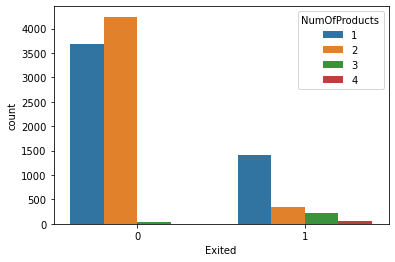

| Exited NumOfProducts | 0 | 1 |
| --- | --- | --- |
| 1 | 0.722856 | 0.277144 |
| 2 | 0.924183 | 0.075817 |
| 3 | 0.172932 | 0.827068 |
| 4 | 0.000000 | 1.000000 |

```python
sns.countplot(df['Exited'], hue=df['NumOfProducts'])
plt.show()
pd.crosstab(df['NumOfProducts'], df['Exited'], normalize='index')
```

**Insights:**

- If we look at the majority, i.e. customers who have 1-2 products, we can say that people with only 1 product will leave more often. Customers with 2 products have the smallest rate of leaving.
- Looking at minority, i.e. customers with 3-4 products, it is curious to see that the bank has lost almost all of them.
- **HasCrCard**

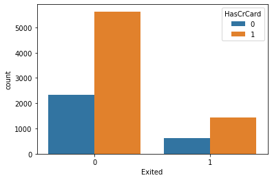

| Exited HasCrCard | 0 | 1 |
| --- | --- | --- |
| 0 | 0.791851 | 0.208149 |
| 1 | 0.798157 | 0.201843 |

```python
sns.countplot(df['Exited'], hue=df['HasCrCard'])
plt.show()
pd.crosstab(df['HasCrCard'], df['Exited'], normalize='index')
```

**Insights:**

- It seems that it does not matter if customer has a credit card, the rate of leaving is the same for both groups.
- **IsActiveMember**

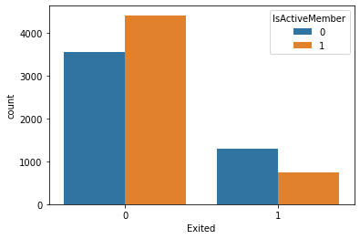

| Exited IsActiveMember | 0 | 1 |
| --- | --- | --- |
| 0 | 0.731491 | 0.268509 |
| 1 | 0.857309 | 0.142691 |

```python
sns.countplot(df['Exited'], hue=df['IsActiveMember'])
plt.show()
pd.crosstab(df['IsActiveMember'], df['Exited'], normalize='index')
```

**Insights:**

- It seems that customers who less active leave more often.

Let's now see numerical variables

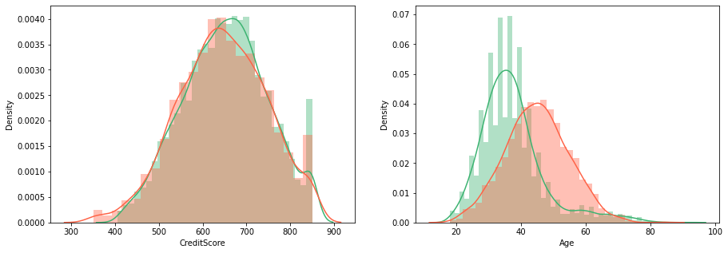

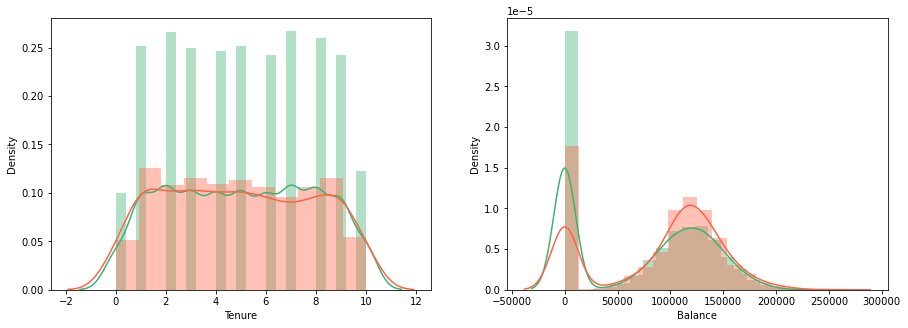

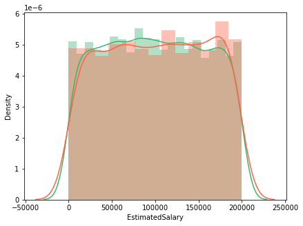

```python
for colset in [['CreditScore', 'Age'], ['Tenure', 'Balance'], ['EstimatedSalary']]:
    plt.figure(figsize=(15,5))

    plt.subplot(1, 2, 1)
    sns.distplot(cdf[cdf['Exited'] == 0][colset[0]], color='mediumseagreen');
    sns.distplot(cdf[cdf['Exited'] == 1][colset[0]], color='tomato');

    if len(colset) == 2:
        plt.subplot(1, 2, 2)
        sns.distplot(cdf[cdf['Exited'] == 0][colset[1]], color='mediumseagreen');
        sns.distplot(cdf[cdf['Exited'] == 1][colset[1]], color='tomato');

    plt.show()
```

**Insights:**

- Visually we can see that almost none of the numeric variables are good predictors. Only exception is the **Age** column where we can observe that older customers (~ above 50) leave more often, and younger customers (~ below 35) tend to stay.

Let's see the correlation between the variables

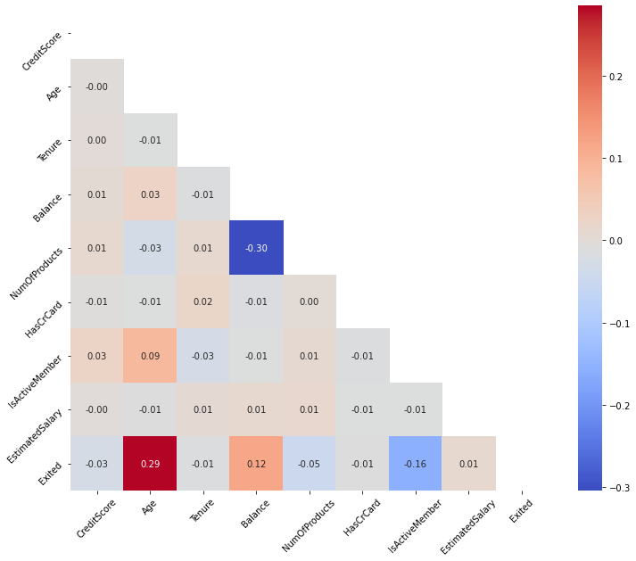

```python
plt.figure(figsize=(12, 10))
mask = np.zeros_like(cdf.corr())
mask[np.triu_indices_from(mask)] = True
heatmap= sns.heatmap(cdf.corr(), annot = True, cmap='coolwarm', fmt='0.2f', cbar = True, mask=mask)
heatmap.set_xticklabels(heatmap.get_xticklabels(), rotation=45, fontweight='light')
heatmap.set_yticklabels(heatmap.get_yticklabels(), rotation=45, fontweight='light')
plt.show()
```

**Insights:**

- As we can see there is no significant correlation. However, as we discovered before, **Age** and **IsActiveMember** have definetely some impact on the target variable.

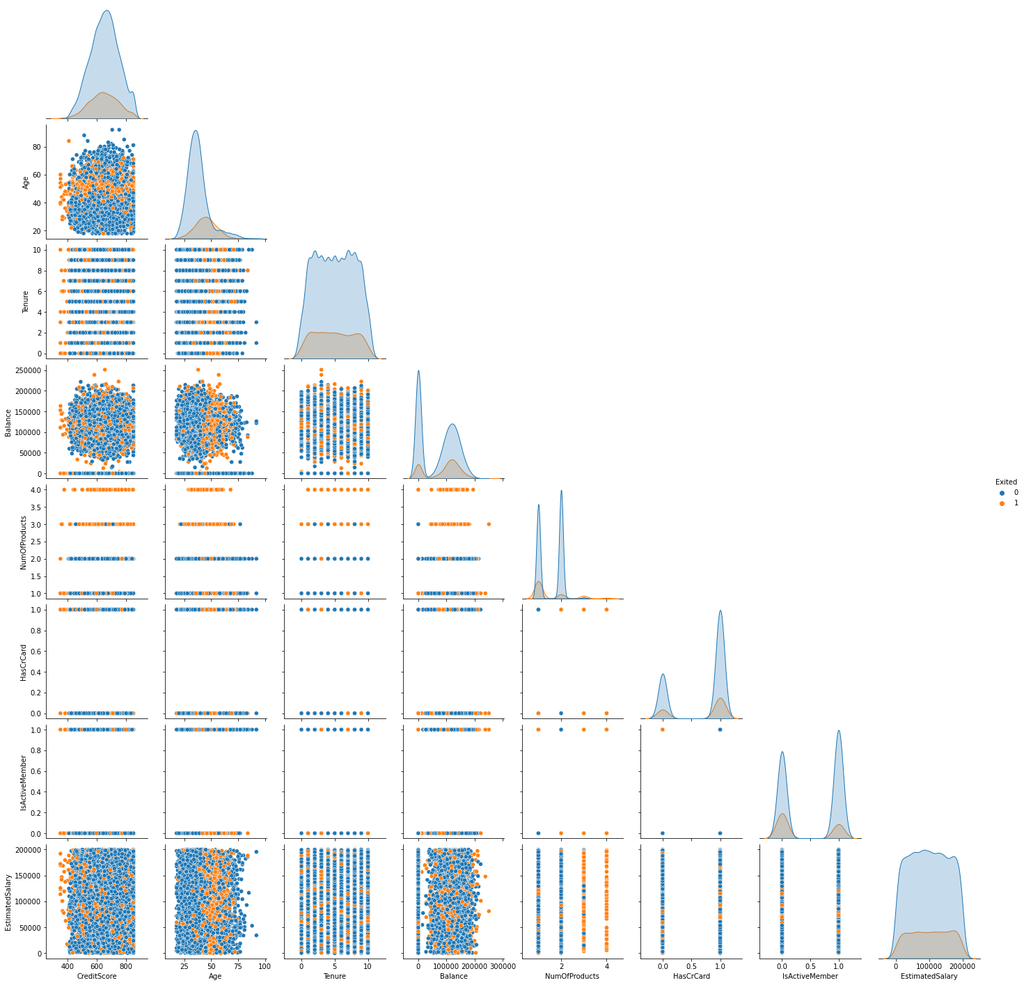

```python
sns.pairplot(cdf, corner=True, diag_kind = 'kde', hue='Exited')
plt.show()
```

**Insights:**

- No good predictors, except the earlier observed case when all the customers with **4 products** have left the bank.

### Getting data ready

```python
ndf = cdf.copy()

# Convert categorical vriables to dummy variables
oneHotCols = ['Geography', 'Gender']
ndf = pd.get_dummies(ndf, columns=oneHotCols, drop_first=True)

# Define X and Y variables
X = ndf.drop('Exited', axis=1)
Y = ndf['Exited']
X.info()
```

```
<class 'pandas.core.frame.DataFrame'>
RangeIndex: 10000 entries, 0 to 9999
Data columns (total 11 columns):
 #   Column             Non-Null Count  Dtype
---  ------             --------------  -----
 0   CreditScore        10000 non-null  int64
 1   Age                10000 non-null  int64
 2   Tenure             10000 non-null  int64
 3   Balance            10000 non-null  float64
 4   NumOfProducts      10000 non-null  int64
 5   HasCrCard          10000 non-null  int64
 6   IsActiveMember     10000 non-null  int64
 7   EstimatedSalary    10000 non-null  float64
 8   Geography_Germany  10000 non-null  uint8
 9   Geography_Spain    10000 non-null  uint8
 10  Gender_Male        10000 non-null  uint8
dtypes: float64(2), int64(6), uint8(3)
memory usage: 654.4 KB
```

Let's split the dataset into **training & test** sets and validate the results.

```python
from sklearn.model_selection import train_test_split

X_train, X_test, y_train, y_test = train_test_split(X, Y, test_size=0.30, random_state=33)
```

```python
def get_percentage(df, subset):
    return len(subset)/len(df.index) * 100

print('{0:0.2f}% data is in training set'.format(get_percentage(ndf, X_train)))
print('{0:0.2f}% data is in test set'.format(get_percentage(ndf, X_test)))
```

```
70.00% data is in training set
30.00% data is in test set
```

```python
def get_count_percentage_df(df, col, value):
    matching_count = len(df[df[col] == value])
    percentage_of_total = (matching_count/len(df.index)) * 100
    return [matching_count, percentage_of_total]

def get_count_percentage_s(s, value):
    matching_count = len(s[s == value])
    percentage_of_total = (matching_count/len(s)) * 100
    return [matching_count, percentage_of_total]

count, percentage = get_count_percentage_df(ndf, 'Exited', 1)
print("Original - Exited 1 : {0} ({1:0.2f}%)".format(count, percentage))
count, percentage = get_count_percentage_df(ndf, 'Exited', 0)
print("Original - Exited 0 : {0} ({1:0.2f}%)".format(count, percentage))
print()
count, percentage = get_count_percentage_s(y_train, 1)
print("Training - Exited 1 : {0} ({1:0.2f}%)".format(count, percentage))
count, percentage = get_count_percentage_s(y_train, 0)
print("Training - Exited 0 : {0} ({1:0.2f}%)".format(count, percentage))
print()
count, percentage = get_count_percentage_s(y_test, 1)
print("Test     - Exited 1 : {0} ({1:0.2f}%)".format(count, percentage))
count, percentage = get_count_percentage_s(y_test, 0)
print("Test     - Exited 0 : {0} ({1:0.2f}%)".format(count, percentage))
```

```
Original - Exited 1 : 2037 (20.37%)
Original - Exited 0 : 7963 (79.63%)

Training - Exited 1 : 1450 (20.71%)
Training - Exited 0 : 5550 (79.29%)

Test     - Exited 1 : 587 (19.57%)
Test     - Exited 0 : 2413 (80.43%)
```

**Insights:**

- Testing & Training datasets have close to original target variable **Exited** distribution, which is good.

Let's now **normalize the training and test data**.

```python
from sklearn.preprocessing import StandardScaler

# Define the scaler
scaler = StandardScaler().fit(X_train)

# Scale the train set
X_train = scaler.transform(X_train)

# Scale the test set
X_test = scaler.transform(X_test)
```

## 3. Building ANN model

So now let us build our ANN model. We know that the bank wants to find out whether clients will leave or not. Also, we know that the bank wants to retain those clients by identifying problems and concentrating on the improvement of its services. In the classification aspect, we want to build a model that performs well in predicting people who may leave and at the same time has minimum **Type II error** i.e. we want to minimize **False Negatives**. False positives are less of an issue because they will be looked at by the bank employees where they can further reduce the error, in contrast, false negatives will be never addressed as they are considered safe by the model. Hence our main metric that we should look at is **Recall**.

Furthermore, we know that our **dataset is imbalanced** towards the clients who stay, this will lead to a model that very good at predicting clients who won't leave resulting in **high values for true negatives**. This means that we cannot rely on **Accuracy** metric as it will always be influenced by the majority class and be very high.

```python
import tensorflow as tf
from tensorflow.keras import Sequential
from tensorflow.keras.layers import Dense
```

```python
classifier = Sequential()
#initializer = tf.keras.initializers.Ones()
#initializer = tf.keras.initializers.LecunUniform()
#initializer = tf.keras.initializers.LecunNormal()
#initializer = tf.keras.initializers.HeNormal()
#initializer = tf.keras.initializers.HeUniform()
initializer = tf.keras.initializers.GlorotUniform() #'uniform'

# Input layer and first hidden layer
classifier.add(Dense(units=12, kernel_initializer=initializer, activation='relu', input_dim=X_train.shape[1]))

# Second hidden layer
classifier.add(Dense(units=6, kernel_initializer=initializer, activation='relu')) #tanh

# Output layer
classifier.add(Dense(units=1, kernel_initializer=initializer, activation='sigmoid'))
```

```python
# Compiling the ANN model
#optimizer = tf.keras.optimizers.RMSprop(learning_rate=0.01)
#optimizer = tf.keras.optimizers.Adam(learning_rate=0.01)
optimizer = tf.keras.optimizers.SGD(learning_rate=0.01)
classifier.compile(loss='binary_crossentropy', optimizer=optimizer , metrics=['accuracy', 'Recall', 'Precision', 'AUC'])

# Fitting the ANN to the Training set
history = classifier.fit(X_train, y_train, batch_size=20, epochs=100, validation_split=0.2, verbose=0)
```

```python
hist  = pd.DataFrame(history.history)
hist['epoch'] = history.epoch
hist.tail()
```

|  | loss | accuracy | recall | precision | auc | val_loss | val_accuracy | val_recall | val_precision | val_auc | epoch |
| --- | --- | --- | --- | --- | --- | --- | --- | --- | --- | --- | --- |
| 95 | 0.333198 | 0.862679 | 0.474472 | 0.758087 | 0.865407 | 0.359125 | 0.856429 | 0.509554 | 0.772947 | 0.852914 | 95 |
| 96 | 0.333163 | 0.862143 | 0.482394 | 0.748634 | 0.865548 | 0.360326 | 0.855714 | 0.458599 | 0.818182 | 0.854065 | 96 |
| 97 | 0.333267 | 0.862143 | 0.478873 | 0.751381 | 0.865343 | 0.359194 | 0.856429 | 0.464968 | 0.815642 | 0.854034 | 97 |
| 98 | 0.332808 | 0.863036 | 0.480634 | 0.755187 | 0.865438 | 0.357532 | 0.857857 | 0.509554 | 0.780488 | 0.854342 | 98 |
| 99 | 0.332773 | 0.861071 | 0.470951 | 0.751405 | 0.865791 | 0.357861 | 0.860000 | 0.528662 | 0.775701 | 0.854065 | 99 |

### Model review

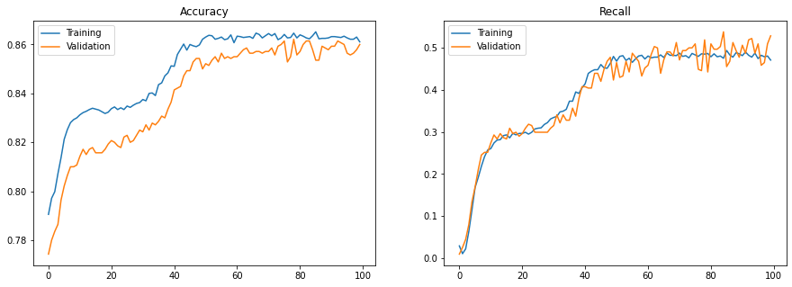

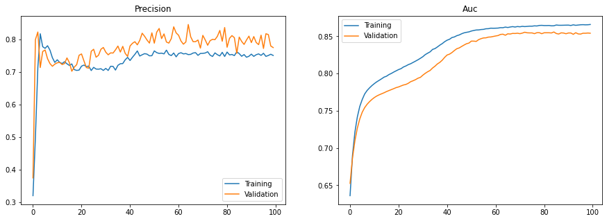

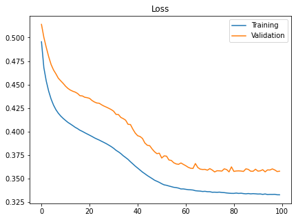

```python
column = True
for colset in [['accuracy', 'val_accuracy'], ['recall', 'val_recall'], ['precision', 'val_precision'], ['auc', 'val_auc'], ['loss', 'val_loss']]:

    if(column):
        plt.figure(figsize=(15,5))

    plt.subplot(1, 2, 1 if column else 2)
    plt.plot(hist[colset[0]])
    plt.plot(hist[colset[1]])
    plt.title(colset[0].capitalize())
    plt.legend(("Training" , "Validation") , loc=0)

    if(not column):
        plt.show()
    column = not column
```

```python
classifier.summary()
```

```
Model: "sequential_25"
_________________________________________________________________
Layer (type)                 Output Shape              Param #
=================================================================
dense_75 (Dense)             (None, 12)                144
_________________________________________________________________
dense_76 (Dense)             (None, 6)                 78
_________________________________________________________________
dense_77 (Dense)             (None, 1)                 7
=================================================================
Total params: 229
Trainable params: 229
Non-trainable params: 0
_________________________________________________________________
```

```python
classifier_evaluation = pd.DataFrame(
        [classifier.evaluate(X_train, y_train, verbose=0), classifier.evaluate(X_test, y_test, verbose=0)],
        columns=classifier.metrics_names,
        index=['Training', 'Testing']
    )

display(classifier_evaluation)
```

|  | loss | accuracy | recall | precision | auc |
| --- | --- | --- | --- | --- | --- |
| Training | 0.336598 | 0.862857 | 0.52000 | 0.740668 | 0.865268 |
| Testing | 0.346479 | 0.852333 | 0.46167 | 0.680905 | 0.849901 |

**Insights:**

- The output of the model varies every run as our model weights are randomly initialized. This makes it difficult to pinpoint the best hyperparameters when it comes to small improvements.
- We have tried various ANN configurations - deep & shallow with a various number of neurons on each layer, different activation functions, initialization distributions, learning rates and optimizers. The best that we could get is **Recall ~0.46** and **Loss ~0.34** on the test dataset without significant overfitting. This possibly points out the fact that we are stuck in a local minimum and cannot completely fit the data. Increasing the number of hidden layers and/or neurons in order to improve decision boundary did not help to improve the situation.
- For this dataset a small ANN of 2 hidden layers (12 and 6 neurons respectively) and simple **Relu** activation function will perform almost the same to a more complex 3-4 hidden layers with 32-8 neurons per layer and **Tanh** activation function.
- Learning rate however drastically affects the abbility of the model to converge. Learning rate of **0.01** showed the best results.
- **SGD** optimizers also performed the best keeping model from overfitting the longest.

### Predicting the results using 0.5 as a threshold

Let's use our model now to predict the classes.

```python
y_pred = (classifier.predict(X_test) > 0.5).astype("int32")
display(y_pred)
```

```
array([[0],
       [0],
       [0],
       ...,
       [0],
       [0],
       [0]], dtype=int32)
```

### Scores and Confusion matrix

#### Define Utility Functions

```python
from sklearn.metrics import roc_auc_score, roc_curve

def report_ROC(estimator, x_te, y_te, roc_auc, title, force_show=True):
    y_pred = estimator.predict(x_te)
    fpr, tpr, thresholds = roc_curve(y_te, y_pred)
    plt.plot(fpr, tpr, label='{} (area = {:0.2f})'.format(title, roc_auc))
    plt.plot([0, 1], [0, 1],'r--')
    plt.xlim([0.0, 1.0])
    plt.ylim([0.0, 1.05])
    plt.xlabel('False Positive Rate')
    plt.ylabel('True Positive Rate')
    plt.title('Receiver operating characteristic')
    plt.legend(loc="lower right")
    if(force_show):
        plt.show()

    return {'fpr': fpr, 'tpr':tpr, 'thresholds': thresholds, 'roc_auc': roc_auc}
```

```python
from sklearn.metrics import confusion_matrix

def cm_report(cm, title, report, force_show=True):
    flat_cm = cm.flatten();
    group_names = ['TN', 'FP', 'FN', 'TP']
    group_counts = ['{}'.format(value) for value in flat_cm]
    labels = [f'{v1}\n{v2}' for v1, v2 in zip(group_names, group_counts)]
    labels = np.asarray(labels).reshape(2,2)
    color_map = { flat_cm[0]:'mediumseagreen', flat_cm[1]:'tomato', flat_cm[2]:'tomato', flat_cm[3]:'mediumseagreen'}
    colors =  [(color_map[index] if index in color_map.keys() else 'black') for index in np.arange(flat_cm.min(), flat_cm.max() + 1)]

    #plt.figure(figsize = (7,5))
    sns.heatmap(cm, annot=labels, fmt='', xticklabels = [0, 1], yticklabels = [0, 1], cmap=colors, cbar = False, annot_kws={"size": 20})
    plt.ylabel('Actual')
    plt.xlabel('Predicted')
    if(force_show):
        plt.show()

    TP = cm.flatten()[3]
    TN = cm.flatten()[0]
    FP = cm.flatten()[1]
    FN = cm.flatten()[2]

    recall = TP/(TP + FN)
    specificity = TN/(FP + TN)
    precision = TP/(TP + FP)
    accuracy = (TP + TN)/(TP + TN + FP + FN)
    error_rate = 1 - accuracy

    report['Accuracy'] = accuracy
    report['Precision'] = precision
    report['Recall/Sensitivity/TPR'] = recall
    report['Specificity/TNR'] = specificity
    report['Error Rate'] = error_rate
    report['TP'] = TP
    report['TN'] = TN
    report['FP'] = FP
    report['FN'] = FN

    return report
```

```python
from sklearn.metrics import recall_score, precision_score, f1_score, accuracy_score, classification_report

def estimator_report(estimator, title, x_te, y_te):
    y_pred = (estimator.predict(x_te) > 0.5).astype("int32")
    f1 = f1_score(y_te, y_pred)
    cm = confusion_matrix(y_te, y_pred)
    roc_auc = roc_auc_score(y_te, y_pred)

    estimator_cm_report = pd.DataFrame(
        [[-1, -1, -1, -1, roc_auc, f1, -1, -1, -1, -1, -1]],
        columns=['Accuracy', 'Precision', 'Recall/Sensitivity/TPR', 'Specificity/TNR', 'ROC AUC', 'F1', 'Error Rate', 'TP', 'TN', 'FP', 'FN'],
        index=[title]
    )

    # Confusion matrix & ROC AUC
    plt.figure(figsize=(15,5))

    plt.subplot(1, 2, 1)
    estimator_cm_report = cm_report(cm, title, estimator_cm_report, False)

    plt.subplot(1, 2, 2)
    roc_report = report_ROC(estimator, x_te, y_te, roc_auc, title, force_show=False)

    plt.show()

    return {'cm': estimator_cm_report, 'roc': roc_report, 'title': title}
```

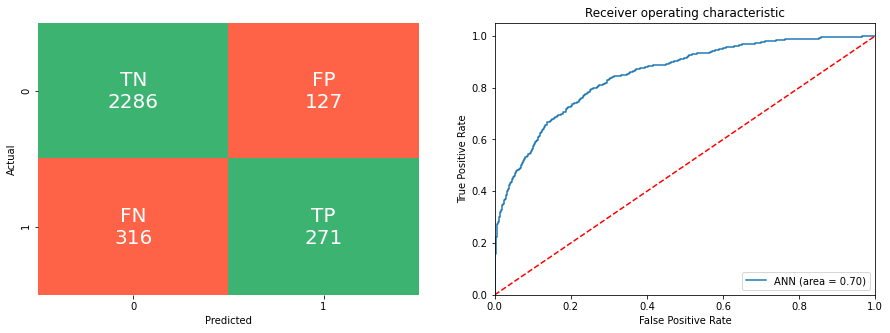

|  | Accuracy | Precision | Recall/Sensitivity/TPR | Specificity/TNR | ROC AUC | F1 | Error Rate | TP | TN | FP | FN |
| --- | --- | --- | --- | --- | --- | --- | --- | --- | --- | --- | --- |
| ANN | 0.852333 | 0.680905 | 0.46167 | 0.947368 | 0.704519 | 0.550254 | 0.147667 | 271 | 2286 | 127 | 316 |

```python
lr_report = estimator_report(classifier, 'ANN', X_test, y_test)
display(lr_report['cm'])
```

**Insights:**

# 4. Conclusions